# Simulation Studies for Non-Parametric Sign Test

Secondly we consider Q-Q plot to compare sample quantiles with theoretical quantiles of standard normal distribution. Let us fix $F$ as exponential distribution with rate parameter $1$. The $Q-Q$ plots for different values of $n$ are shown below:-

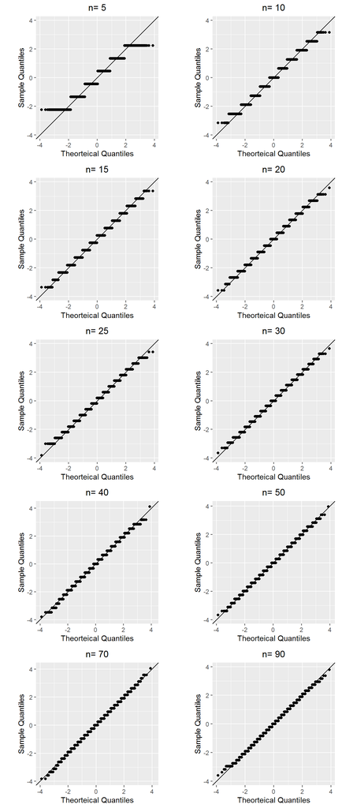

As distribution of $T'$ is discrete so it does not have unique quantiles, specifically for lower values of $n$. Thus it can be seen that in most of the cases same sample quantile is re plotted against different theoretical qunatiles. However, this problem reduces as $n$ increases and we can observe that the points almost lie around the line $x=y$. The next plots are for $U(-3,3)$ CDF.

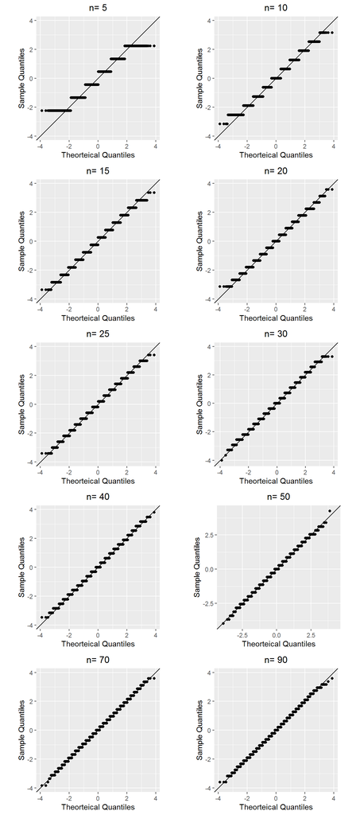

So we can see that in both the cases the plots yield similar results about convergence of the distribution of $T'$ as the sample quantiles tend to match with population conterparts for larger values of $n$ . The presentation shared via the link :- https://bhargob30.shinyapps.io/bhargob3/ shows the $Q-Q$ plots for all other distributions considered and for values of $n$ in the range $1-100$. The conclusions are similar in every case.

Finally we compare the empirical distribution function of $T'$ with the CDF of standard normal distribution. Let us choose $F$ as beta distribution of first kind with parameter $0.8$ and $0.8$. For different values of $n$ we present comparison of empirical CDF with the normal CDF.

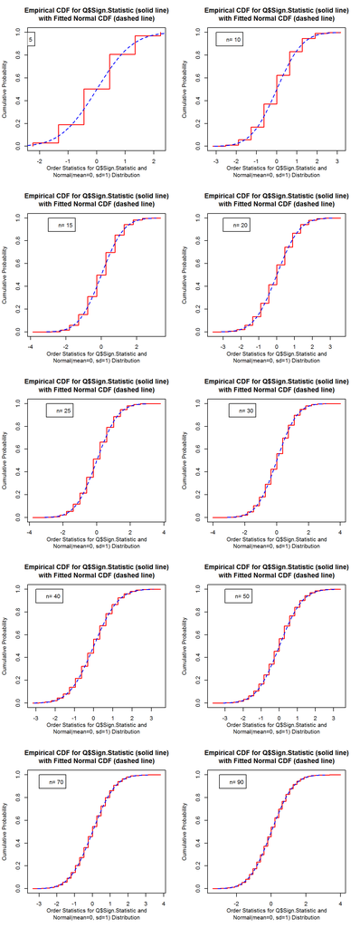

It can be senn that as $n$ increases the difference between the empirical CDF and normal CDF reduces. Next we consider a beta distribution with parameter $5$ and $2$. The plots are shown below:-

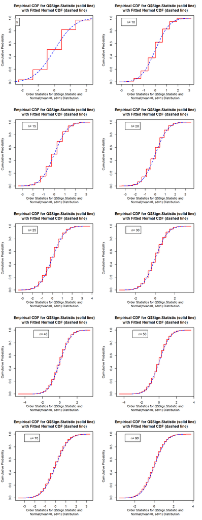

We have created an interactive plot which is presented in the link :- https://bhargob30.shinyapps.io/bhargob4/.

Based on all these observations, we can say that $T'$ converges to $N(0,1)$ variate for all choices of $F$.

## 5.1 2-Sample KS Test

The testing problem in the 2-Sample KS Test is

$$H_{0}:F_{1} = F_{2} \quad vs \quad H_{1}:F_{1} \neq F_{2}$$
where $F_{1}$ and $F_{2}$ are absolutely continuous. Here the test statistic is

$$D_{n,m}=\sup\limits_{-\infty \leq x \leq \infty}|\hat{F}_{1,n}(x)-\hat{F}_{2,m}(x)|$$
and we reject $H_{0}$ for large values of $D_{n,m}$.

Here we construct the sign statistic based on observation from two different distributions and call the two different distributions as $F_{1}$ and $F_{2}$ i.e. for example in the Uniform versus Normal Case we take $F_{1}=\text{distribution function of the sign statistics constructed from the observations from }U[0,1]$ and $F_{2}=\text{distribution function of the sign statistics constructed from the observations from }N(0,1)$. Clearly both $F_{1}$ and $F_{2}$ are not absolutely continuous.Although the assumprtions are not met we perform Kolmogorov-Smirnov two sample test to see whether the distributions are same.

### 5.1.1 Uniform vs Normal-

result is given for sample size $n=22,39,54,158$ sequentially.

```
##
##  Two-sample Kolmogorov-Smirnov test
##
## data:  apply((sign(Tunif.simulation(22, 10000, 0)) + 1)/2, 2, sum) and apply((sign(Tnorm.simulation(22, 10000, 0)) + 1)/2, 2, sum)
## D = 0.0082, p-value = 0.8898
## alternative hypothesis: two-sided
```

```
##
##  Two-sample Kolmogorov-Smirnov test
##
## data:  apply((sign(Tunif.simulation(39, 10000, 0)) + 1)/2, 2, sum) and apply((sign(Tnorm.simulation(39, 10000, 0)) + 1)/2, 2, sum)
## D = 0.0128, p-value = 0.3857
## alternative hypothesis: two-sided
```

```
##
##  Two-sample Kolmogorov-Smirnov test
##
## data:  apply((sign(Tunif.simulation(54, 10000, 0)) + 1)/2, 2, sum) and apply((sign(Tnorm.simulation(54, 10000, 0)) + 1)/2, 2, sum)
## D = 0.0088, p-value = 0.8335
## alternative hypothesis: two-sided
```

```
##
##  Two-sample Kolmogorov-Smirnov test
##
## data:  apply((sign(Tunif.simulation(158, 10000, 0)) + 1)/2, 2, sum) and apply((sign(Tnorm.simulation(158, 10000, 0)) + 1)/2, 2, sum)
## D = 0.0042, p-value = 1
## alternative hypothesis: two-sided
```

### 5.1.2 Exponential vs Normal-

result is given for sample size $n=11,29,65,87$ sequentially.

```
##
##  Two-sample Kolmogorov-Smirnov test
##
## data:  apply((sign(Texp.simulation(11, 10000, 0.369)) + 1)/2, 2, sum) and apply((sign(Tnorm.simulation(11, 10000, 0)) + 1)/2, 2, sum)
## D = 0.0112, p-value = 0.5573
## alternative hypothesis: two-sided
```

```
##
##  Two-sample Kolmogorov-Smirnov test
##
## data:  apply((sign(Texp.simulation(29, 10000, 0.369)) + 1)/2, 2, sum) and apply((sign(Tnorm.simulation(29, 10000, 0)) + 1)/2, 2, sum)
## D = 0.0056, p-value = 0.9976
## alternative hypothesis: two-sided
```

```
##
##  Two-sample Kolmogorov-Smirnov test
##
## data:  apply((sign(Texp.simulation(65, 10000, 0.369)) + 1)/2, 2, sum) and apply((sign(Tnorm.simulation(65, 10000, 0)) + 1)/2, 2, sum)
## D = 0.0074, p-value = 0.9471
## alternative hypothesis: two-sided
```

```
##
##  Two-sample Kolmogorov-Smirnov test
##
## data:  apply((sign(Texp.simulation(87, 10000, 0.369)) + 1)/2, 2, sum) and apply((sign(Tnorm.simulation(87, 10000, 0)) + 1)/2, 2, sum)
## D = 0.0093, p-value = 0.7801
## alternative hypothesis: two-sided
```

### 5.1.3 Exponential vs Beta-

result is given for sample size $n=18,27,43,89$ sequentially.

```
##
##  Two-sample Kolmogorov-Smirnov test
##
## data:  apply((sign(Texp.simulation(18, 10000, 0.369)) + 1)/2, 2, sum) and apply((sign(Tbeta.simulation(18, 10000, -0.5)) + 1)/2, 2, sum)
## D = 0.0108, p-value = 0.6042
## alternative hypothesis: two-sided
```

```
##
##  Two-sample Kolmogorov-Smirnov test
##
## data:  apply((sign(Texp.simulation(27, 10000, 0.369)) + 1)/2, 2, sum) and apply((sign(Tbeta.simulation(27, 10000, -0.5)) + 1)/2, 2, sum)
## D = 0.007, p-value = 0.9671
## alternative hypothesis: two-sided
```

```
##
##  Two-sample Kolmogorov-Smirnov test
##
## data:  apply((sign(Texp.simulation(43, 10000, 0.369)) + 1)/2, 2, sum) and apply((sign(Tbeta.simulation(43, 10000, -0.5)) + 1)/2, 2, sum)
## D = 0.0106, p-value = 0.628
## alternative hypothesis: two-sided
```

```
##
##  Two-sample Kolmogorov-Smirnov test
##
## data:  apply((sign(Texp.simulation(89, 10000, 0.369)) + 1)/2, 2, sum) and apply((sign(Tbeta.simulation(89, 10000, -0.5)) + 1)/2, 2, sum)
## D = 0.0055, p-value = 0.9982
## alternative hypothesis: two-sided
```

### 5.1.4 Cauchy vs Beta-

result is given for sample size $n=43,49,68,87$ sequentially.

```
##
##  Two-sample Kolmogorov-Smirnov test
##
## data:  apply((sign(Tcauchy.simulation(43, 10000, 0)) + 1)/2, 2, sum) and apply((sign(Tbeta.simulation(43, 10000, -0.5)) + 1)/2, 2, sum)
## D = 0.0084, p-value = 0.8722
## alternative hypothesis: two-sided
```

```
##
##  Two-sample Kolmogorov-Smirnov test
##
## data:  apply((sign(Tcauchy.simulation(49, 10000, 0)) + 1)/2, 2, sum) and apply((sign(Tbeta.simulation(49, 10000, -0.5)) + 1)/2, 2, sum)
## D = 0.0078, p-value = 0.9213
## alternative hypothesis: two-sided
```

```
##
##  Two-sample Kolmogorov-Smirnov test
##
## data:  apply((sign(Tcauchy.simulation(68, 10000, 0)) + 1)/2, 2, sum) and apply((sign(Tbeta.simulation(68, 10000, -0.5)) + 1)/2, 2, sum)
## D = 0.0071, p-value = 0.9626
## alternative hypothesis: two-sided
```

```
##
##  Two-sample Kolmogorov-Smirnov test
##
## data:  apply((sign(Tcauchy.simulation(87, 10000, 0)) + 1)/2, 2, sum) and apply((sign(Tbeta.simulation(87, 10000, -0.5)) + 1)/2, 2, sum)
## D = 0.0124, p-value = 0.4255
## alternative hypothesis: two-sided
```

Although all the above result is perfect with very high p-value and small value of the test statistic $D$, We cannot interpret these result due to non applicability of the Kolmogorov-Smirnov test.

## 5.2 1-Sample KS Test

The testing problem in the 1-Sample KS Test is

$$H_{0}:F=F_{0} \quad vs \quad H_{1}:F \neq F_{0}$$
where $F$ and $F_{0}$ are absolutely continuous. With the test statistic

$$D_{n}=\sup\limits_{x\in\mathbb{R}} |\hat{F}_{n}(x)-F_{0}(x)|$$

which rejects $H_{0}$ for large values of $D_{n}$.

We now perform one sample Kolmogorov-Smirnov Test. Here we take the null distribution as $F_{0}=\text{distribution function of } Bin(n,\frac{1}{2})$ and true distribution $F=\text{distribution function of sign statistic }S$. Note that here the true as well as the hypothesized distribution under null are not absolutely continuous. But still we perform this test to see what kind of result it gives.

We give the result of sampling from the cauchy distribution with sample size $n=60,22$ respectively. Clearly in this case it is giving completely absurd results.

```
##
##  One-sample Kolmogorov-Smirnov test
##
## data:  apply((sign(Tcauchy.simulation(60, 10000, 0)) + 1)/2, 2, sum)
## D = 0.10579, p-value < 2.2e-16
## alternative hypothesis: two-sided
```

```
##
##  One-sample Kolmogorov-Smirnov test
##
## data:  apply((sign(Tcauchy.simulation(22, 10000, 0)) + 1)/2, 2, sum)
## D = 0.16339, p-value < 2.2e-16
## alternative hypothesis: two-sided
```

For testing asymptotic normality also we perform kolmogorov-Smirnov test.Here we take the null distribution as $F_{0}=\text{distribution function of } N(0,1)$ and true distribution $F=\text{distribution function of sign statistic }S$. Note that although the hypothesized distribution under null is absolutely continuous, the true distribution is discrete. But still we perform this test without bothering about the assumptions of the KS Test to see what kind of result it gives.

We give the result for sample size $n=60,90,150,200$ sequentially. Although the p-value is incresing for increasing n, the p-values are not interpretable.

```
##
##  One-sample Kolmogorov-Smirnov test
##
## data:  (2 * apply((sign(Tcauchy.simulation(60, 10000, 0)) + 1)/2, 2,     sum) - 60)/sqrt(60)
## D = 0.0539, p-value < 2.2e-16
## alternative hypothesis: two-sided
```

```
##
##  One-sample Kolmogorov-Smirnov test
##
## data:  (2 * apply((sign(Tcauchy.simulation(90, 10000, 0)) + 1)/2, 2,     sum) - 90)/sqrt(90)
## D = 0.0444, p-value < 2.2e-16
## alternative hypothesis: two-sided
```

```
##
##  One-sample Kolmogorov-Smirnov test
##
## data:  (2 * apply((sign(Tcauchy.simulation(150, 10000, 0)) + 1)/2, 2,     sum) - 150)/sqrt(150)
## D = 0.042459, p-value = 4.441e-16
## alternative hypothesis: two-sided
```

```
##
##  One-sample Kolmogorov-Smirnov test
##
## data:  (2 * apply((sign(Tcauchy.simulation(200, 10000, 0)) + 1)/2, 2,     sum) - 200)/sqrt(200)
## D = 0.034269, p-value = 1.262e-10
## alternative hypothesis: two-sided
```

## 5.3 Shapiro Wilk Normality Test

We now perform Shapiro-Wilks test for checking normality with the value of the statistic

$$\dfrac{2T-n}{\sqrt{n}}$$
In shapiro wilk’s test

- Null hypothesis : $X_{1}, X_{2},\dots,X_{n} \overset{iid}{\sim} \mathcal{N}(\mu,\sigma^{2}),$ for some $\mu$ and $\sigma^{2}$.
- Test statistic :

$$W= {{(\sum_{i=1}^{n} {a_{i}X_{(i)}})^{2}} \over \sum_{i=1}^{n} {(X_{i}-\bar{X})^{2}} }$$

- where

$$\textbf{a}= {{m^{T}V}\over \sqrt{m^{T}V^{-1}V^{-1}m}}$$

- where $m$ and $V$ are mean vector and variance-covariance matrix of $(Z_{(1)},\dots,Z_{(n)})^{T}$, where $Z_{1}, Z_{2},\dots,Z_{n} \overset{iid}{\sim} \mathcal{N}(0,1).$

Below we have given the result for sample sizes $n=10,50,90,130$ sequentially. Although the p-values are incresing for increaing n, the p-values are too small to show something meaningful, may be this is due to the discrete nature of the sign statistic.

```
##
##  Shapiro-Wilk normality test
##
## data:  (2 * apply((sign(Tcauchy.simulation(10, 3000, 0)) + 1)/2, 2,     sum) - 10)/sqrt(10)
## W = 0.96415, p-value < 2.2e-16
```

```
##
##  Shapiro-Wilk normality test
##
## data:  (2 * apply((sign(Tcauchy.simulation(50, 3000, 0)) + 1)/2, 2,     sum) - 50)/sqrt(50)
## W = 0.99229, p-value = 1.385e-11
```

```
##
##  Shapiro-Wilk normality test
##
## data:  (2 * apply((sign(Tcauchy.simulation(90, 3000, 0)) + 1)/2, 2,     sum) - 90)/sqrt(90)
## W = 0.99578, p-value = 1.632e-07
```

```
##
##  Shapiro-Wilk normality test
##
## data:  (2 * apply((sign(Tcauchy.simulation(130, 3000, 0)) + 1)/2, 2,     sum) - 130)/sqrt(130)
## W = 0.99681, p-value = 5.815e-06
```

# 6 Parametric test versus Non-parametric test

In this section we will be comparing the sign test with some of its parametric test versions. The sign test is used for testing the location parameter (most of the times median) of an absolutely continuous distribution. We will mainly consider two parametric tests which also test for location viz. one sample $t$ test and $z$ test. Depending upon whether the variance of the underlying distribution is known or unknown we can use $z$ test or $t$ test. In our case, as we are drawing sample from known distributions, so we have the information about the variance. Thus we can use both the tests.  
Our comparison will be mainly based on size and power of the tests. We will be observing under what circumstances the performance of parametric tests is superior to the sign test. It will be also observed that when the underlying assumptions violate exactly opposite things happen.

In the first part of this section we will compare the sizes of the sign test with $t$ test and $z$ test. Since both the parametric tests are valid under the conditions that $X_1, X_2 \dots X_n$ are drawn from normal distribution. So let us take $F$ as $N(50,100)$ distribution, $\alpha=0.05$ and a right tailed test. Firstly we will consider the parametric version as the $z$ test. Then the following table shows the simulated sizes of both the parametric and non -parametric tests:-

```
##   n non.parametric.test parametric.test
##   5              0.0326          0.0138
##  10              0.0109          0.0330
##  15              0.0200          0.0392
##  20              0.0196          0.0407
##  25              0.0219          0.0429
##  30              0.0476          0.0424
##  35              0.0455          0.0461
##  40              0.0411          0.0458
##  45              0.0335          0.0453
##  50              0.0322          0.0454
```

For $n=5$, and $n=30$ the simulated size for $z$ test is less than that of sign test. However, the simulated sizes of $z$ test are much more closer to chosen $\alpha=0.05$. For non parametric tests, sometimes the size becomes close to $0.05$, but most of the times lies below $0.04$. It is expected that the sizes become much more closer to $0.05$ as $n$ increases. We present the following plot showing the behavior of simulated sizes for both the tests with $n$.

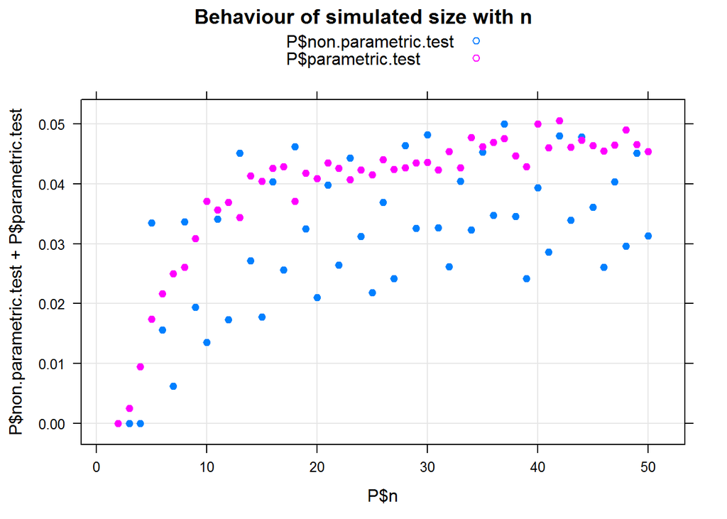

The sizes for both the tests show an increasing pattern. However, the spread of the points in case of parametric test is less. It shows a steady pattern of approaching to $0.05$. On the other hand, the sizes of sign test are scattered.

Next we compare the results of sign test with $t$ test. We are keeping all the parameters (viz. $F, \alpha$, direction etc.) fixed as considered as above.

```
##   n non.parametric.test parametric.test
##   5              0.0326          0.0506
##  10              0.0109          0.0518
##  15              0.0200          0.0527
##  20              0.0196          0.0451
##  25              0.0219          0.0489
##  30              0.0476          0.0473
##  35              0.0455          0.0521
##  40              0.0411          0.0511
##  45              0.0335          0.0490
##  50              0.0322          0.0494
```

This time the simulated sizes of $t$ test appears to be very close to $\alpha=0.05$. As opposed to $z$ test, the simulated sizes are more or less equal to $0.05$ even for small $n$. The graph also shows the same thing:-

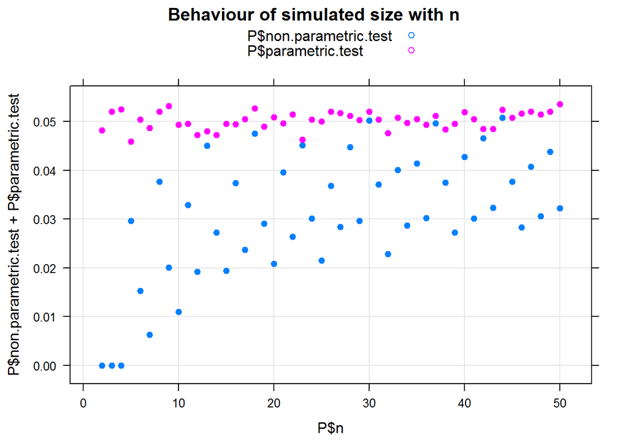

Now, we will see how a deviation of the sampled population from the normality results in simulated sizes of parametric tests. For this we will choose different $F$ and examine the above results. At first we take $F$ as cauchy distribution with location $0$ and scale $1$. The other parameters being same as earlier. We are taking the parametric test as $t$ test because variance of Cauchy distribution does not exist. The results are as follows:-

```
##   n non.parametric.test parametric.test
##   5              0.0325          0.0255
##  10              0.0104          0.0279
##  15              0.0151          0.0283
##  20              0.0203          0.0301
##  25              0.0205          0.0277
##  30              0.0519          0.0296
##  35              0.0409          0.0292
##  40              0.0446          0.0301
##  45              0.0343          0.0335
##  50              0.0313          0.0312
```

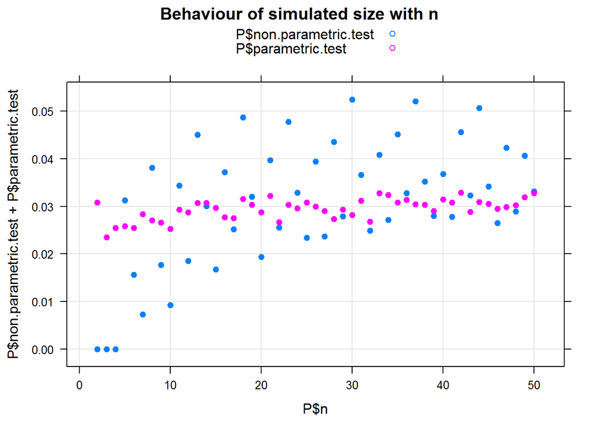

When the sampled distribution has been changed from normal to Cauchy, the $t$ statistic considered in the one sample $t$ test no longer follows $t$ distribution. So, the simulated sizes will not give estimates of $\alpha$ as the critical points change in this case. From the figure as well as the plot shown above we see that the simulated sizes of $t$ test have not touched even $0.05$ and lies around $0.03$.

Next we consider $F$ as exponential distribution with parameter $1$. Keeping all other parameters same with the previous discussion. If we consider $z$ test as the parametric test, we get the following results:-

```
##   n non.parametric.test parametric.test
##   5              0.0332          0.0332
##  10              0.0099          0.0499
##  15              0.0170          0.0527
##  20              0.0219          0.0522
##  25              0.0200          0.0545
##  30              0.0506          0.0535
##  35              0.0441          0.0535
##  40              0.0366          0.0518
##  45              0.0343          0.0562
##  50              0.0331          0.0515
```

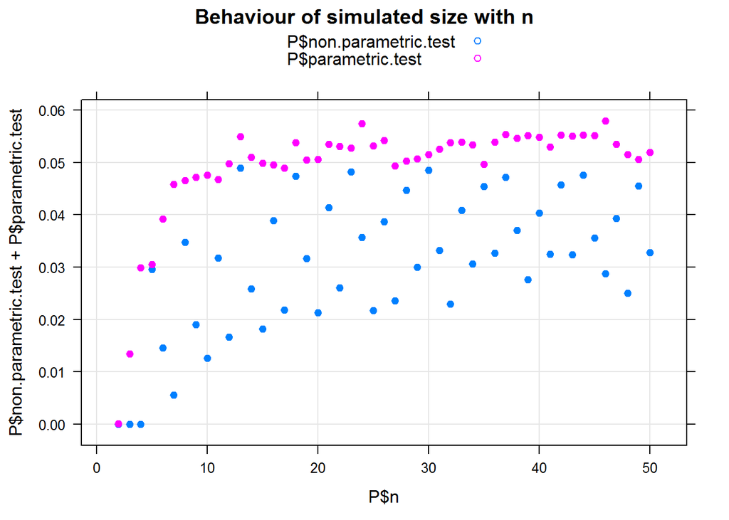

This time we see that the sizes for the $z$ test remains less than $0.05$ for small values of $n$. But gradually it starts increasing and rarely falls below $0.05$ for higher values of $n$. This indicates that the probability of Type I error is slightly greater than the chosen $\alpha$. But we would like to point out that for large values of $n$, irrespective of the distribution $F$, the $z$ test statistic would show normality because of CLT. So changing $F$ should not have any effect on estimated size of the $z$ test for large $n$

In order to observe the pattern of sizes for other deviations (i.e. other choices of $F$) we have made the following interactive presentation where $F$, $\alpha$, direction, and appropriate version of the parametric test can be chosen.

The results can be seen through the following link:- https://bhargob30.shinyapps.io/bhargob1/

In the following part of this section we will be comparing the sign test with the parametric counterparts on the basis of simulated power and the ability to distinguish a value close to the value specified by $H_0$. We know that parametric tests are uniformly most powerful tests when we consider one tailed test and all the assumptions hold. So, we expect them to have higher power as compared to the sign test. We will verify this first. After that we will show that sometimes non parametric tests dominate parametric ones when the assumptions are not made.

Let us take $F$ as $N(0,1)$ distribution. Fix other parameters as follows:- $\alpha=0.10$, $\theta_1=-0.1$, direction$=$left tailed, the parametric counterpart $=z$-test. The estimated powers of both the sign test and $z$-test corresponding to different values of $n$ are given below:-

```
##     n non.parametric.test parametric.test
##    10              0.0204          0.0627
##    20              0.0442          0.1022
##    40              0.1075          0.1501
##    60              0.1484          0.1899
##    80              0.1634          0.2199
##   100              0.1798          0.2529
##   150              0.2320          0.3404
##   300              0.3820          0.5261
##   500              0.5548          0.7128
##   800              0.7175          0.8800
##  1000              0.8025          0.9362
##  1500              0.9195          0.9876
##  2000              0.9743          0.9983
```

As we expected, the simulated power of the $z$ test is more than that of sign test for each value of $n$. From the table it also becomes clear that the power of $z$ test also reaches $1$ as $n$ increases indefinitely but at a faster rate than sign test. The following plot of simulated size versus $n$ for both the tests also reflect the same thing:-

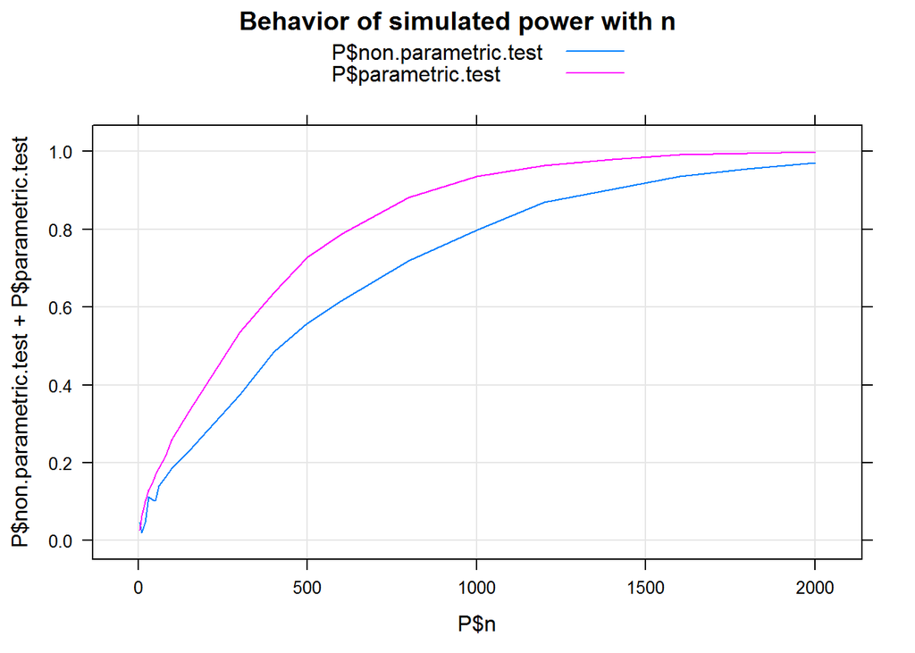

Thus irrespective of the value of $n$, $z$ test has more power. Now we examine the same thing for $t$ test. This time the table and the plot are as follows:-

```
##     n non.parametric.test parametric.test
##    10              0.0207          0.0885
##    20              0.0484          0.1119
##    40              0.1019          0.1538
##    60              0.1393          0.1867
##    80              0.1735          0.2242
##   100              0.1823          0.2626
##   150              0.2329          0.3390
##   300              0.3867          0.5370
##   500              0.5490          0.7238
##   800              0.7316          0.8787
##  1000              0.8055          0.9375
##  1500              0.9229          0.9862
##  2000              0.9730          0.9978
```

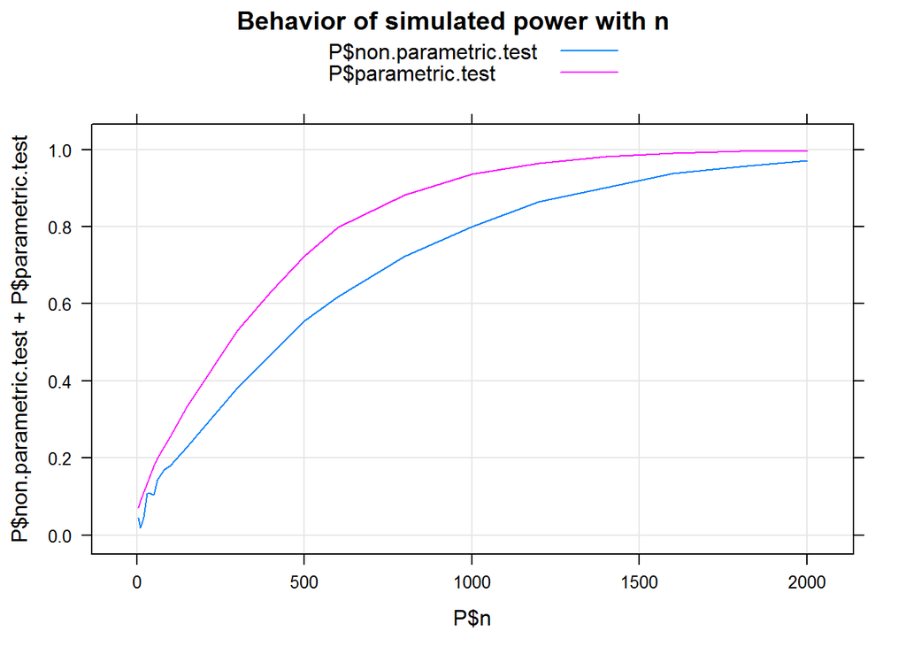

Both the table as well as the plot shows that the power of $t$ test is higher than sign test. Based on the above results we can claim that a parametric tests higher chance of distinguishing a value of $\theta$ close to null value. Thus we recommend parametric tests over sign test when we have enough evidence about the normality of the population.

Similarly we can choose right tailed or two tailed tests and can show that parametric tests outperform the sign test in all the cases. This is shown in interactive presentation whose link is shared below.

However, it may be difficult in practical situation to meet the assumption of normality. In fact there often seems to have a departure from normality. Now, we will see how a departure from normality will affect the powers of parametric tests. We will be mainly interested in observing if they still remain most powerful.

For this let us take $F$ as CDF of $t$ distribution with $5$ d.f. Let $\alpha=0.01$, direction of the test =right tailed, the parametric version=$z$ test, and $\theta_1=0.3$. Then we have the simulated sizes as follows:-

```
##     n non.parametric.test parametric.test
##    10              0.0074          0.0206
##    20              0.0596          0.0649
##    40              0.1529          0.1634
##    60              0.2332          0.2806
##    80              0.3629          0.3783
##   100              0.3982          0.4799
##   150              0.6542          0.6832
##   300              0.9388          0.9545
##   500              0.9970          0.9985
##   800              1.0000          1.0000
##  1000              1.0000          1.0000
##  1500              1.0000          1.0000
##  2000              1.0000          1.0000
```

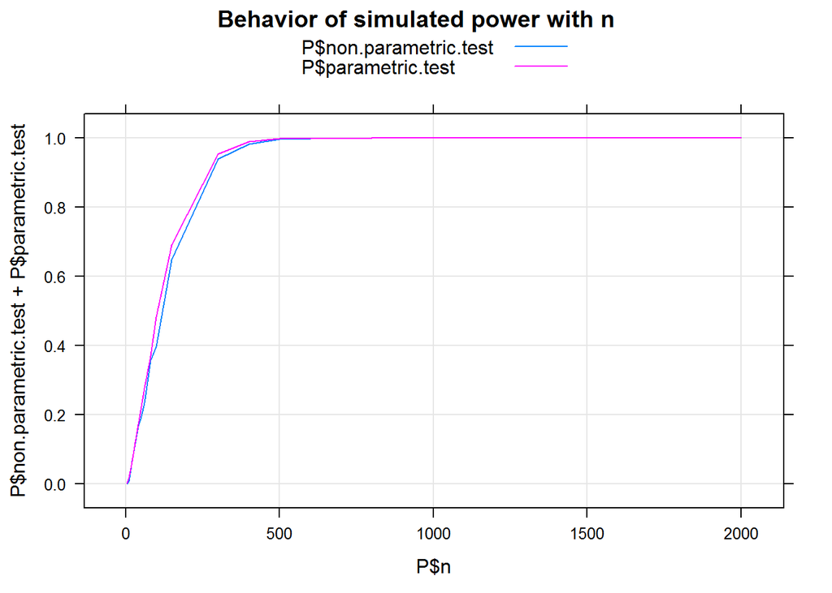

We can see that the powers of sign test appears slightly lower but very close to that of $z$ test. The two curves almost overlap each other. Let us see what happens in case of $t$ test:-

```
##     n non.parametric.test parametric.test
##    10              0.0074          0.0487
##    20              0.0596          0.0912
##    40              0.1529          0.1948
##    60              0.2332          0.3098
##    80              0.3629          0.4025
##   100              0.3982          0.4949
##   150              0.6542          0.6886
##   300              0.9388          0.9508
##   500              0.9970          0.9973
##   800              1.0000          1.0000
##  1000              1.0000          1.0000
##  1500              1.0000          1.0000
##  2000              1.0000          1.0000
```

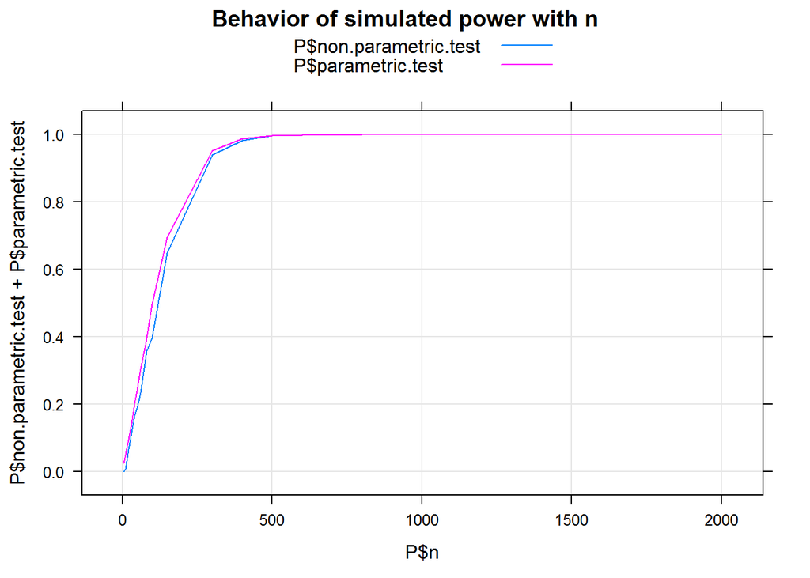

Sign test tend to perform similarly with $t$ test in this case also. So unlike the case when $F$ was $N(0,1)$, this time sign test does not perform worse in terms of size.

Below we have considered some other $F$’s and shown the above plot for each such choice. We are taking the parametric version as $t$ test.

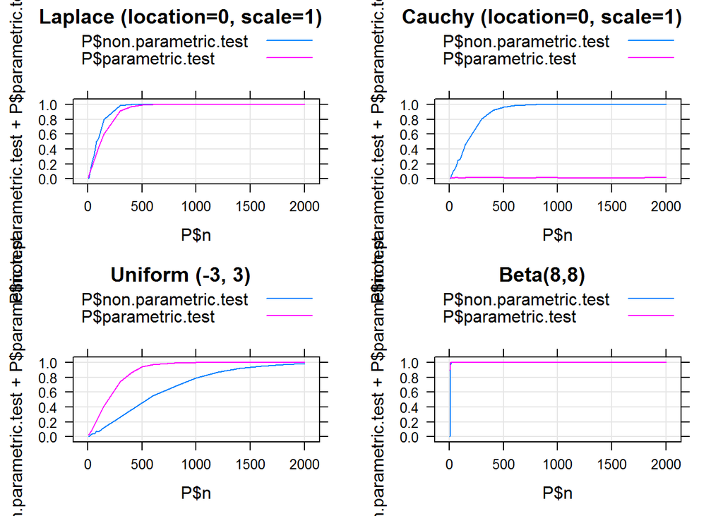

We have created a similar kind of `shiny` presentation like the earlier cases where we can choose $F$, $\alpha, \theta_1$, direction of the test, and the parametric test version. A table as well as a plot of simulated powers versus $n$ will be shown for each of the sign test and the chosen parametric test. It can be accessed via the following link:- https://bhargob30.shinyapps.io/bhargob2/

Next we fix will study the behavior of power function for different values of $\theta_1$ (depending on direction of the tail of the test) and fixed $n$. Like the previous case we will first assume that conditions hold. So we choose $F$ as CDF of $N(50, 100)$ distribution, $\alpha=0.10$, $n=20$, the parametric counterpart=$t-$test, direction= right tailed test. The powers of both the tests corresponding to different $\theta_1$’s are as follows:-

```
##  theta1 non.parametric.test parametric.test
##     0.1              0.0585          0.1045
##     0.2              0.0658          0.1145
##     0.4              0.0725          0.1312
##     0.6              0.0892          0.1531
##     0.8              0.0989          0.1836
##     1.0              0.1059          0.1949
##     1.4              0.1362          0.2492
##     1.6              0.1596          0.2838
##     2.0              0.1975          0.3512
##     2.5              0.2397          0.4238
##     3.0              0.3054          0.5146
##     3.5              0.3779          0.6074
##     4.0              0.4351          0.6828
```

We have seen that the parametric tests results in higher power for each of the value of $\theta_1$. The graphical presentation of the same is shown below:-

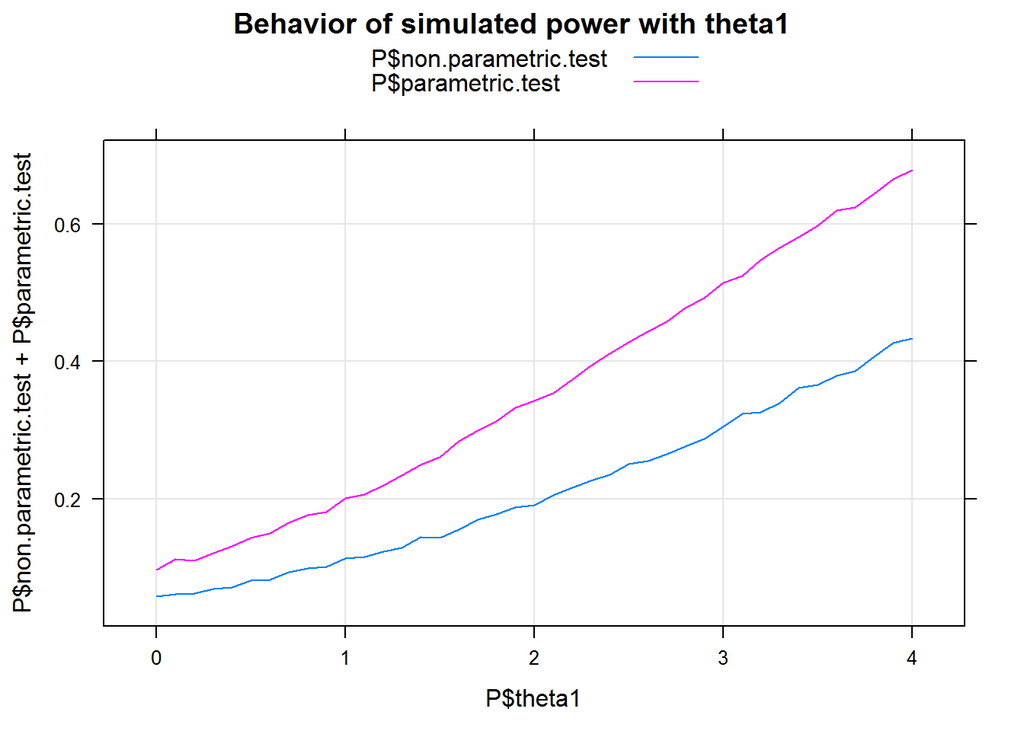

As we one sided parametric tests are UMP tests so we expect them to have higher power than sign test uniformly over all the values of $\theta_1$. Similar plot is shown when the parametric counterpart is $z$- test:-

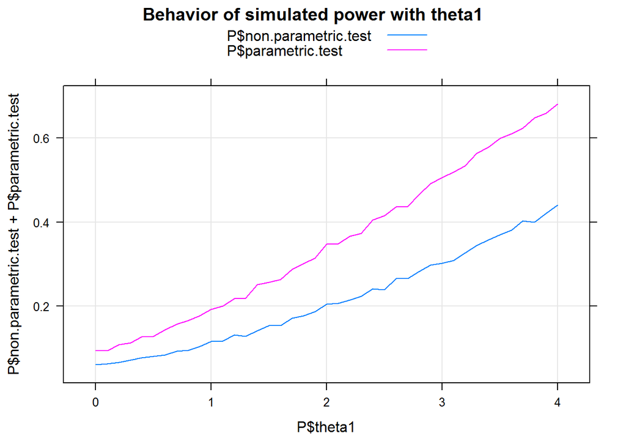

So, as we claimed earlier $t$ and $z$ tests perform well when all the assumptions are met. Using the interactive link shared below we can get similar plots for different $n$, $\alpha$, direction etc.

Let us now see what happens when $F$ is not normal. Suppose we first take $F$ as laplace CDF as mentioned earlier. Keeping all other things fixed we get the following plot:-

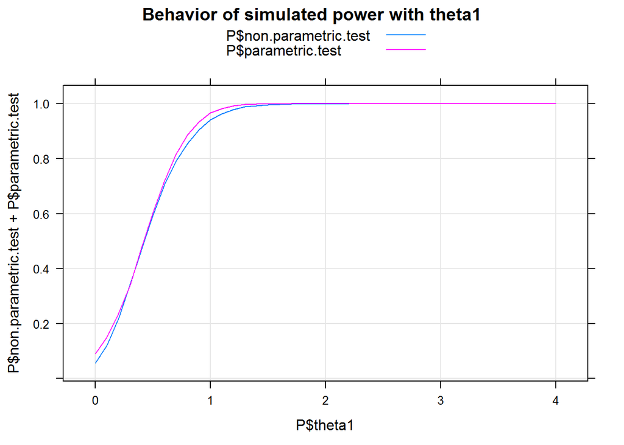

So it is seen that sign test has more or less similar power as $z$-test. Similarly when we take $F$ as Cauchy and consider $t$-test then we obtain the following plot:-

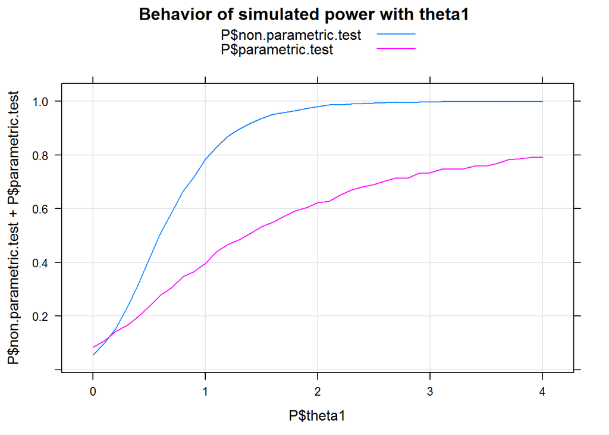

This time sign test outperform $t$-test. Thus when the assumption of normality is violated the parametric tests may tend to show poor performance than non-parametric tests. In other words, when we are not sure about the underlying assumption of normality it is better to use sign test as we will not be doing worse than $z$ test. In fact in the last case we achieved higher power.

However, sometimes parametric tests still perform better despite choosing $F$ different from normal distribution. This can be seen from the following plots where we have taken different choices of $F$’s. The choice of $F$ and parametric test is shown in the top of each plot.

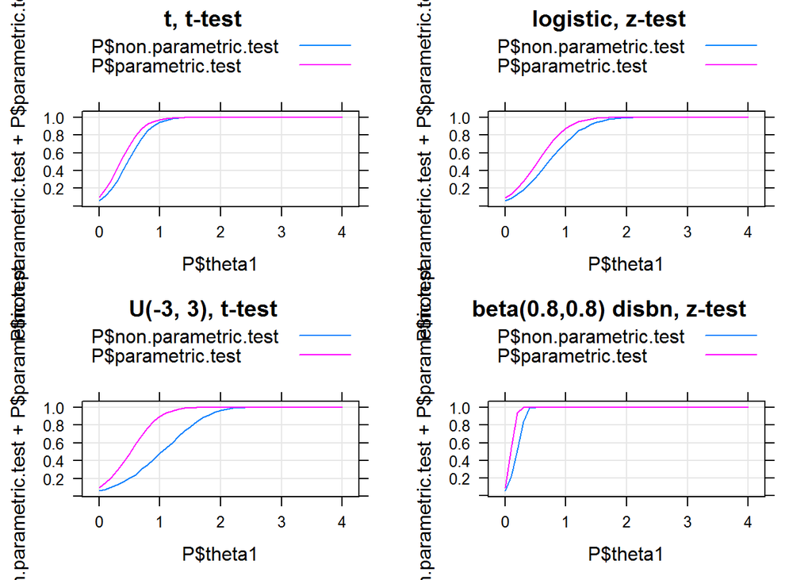

We can similarly take different choices of $n$, $\alpha$, different versions of $H_1$ etc and compare the simulated powers of both the tests. The following link will redirect to a `shiny` presentation of the same. We can choose the distribution $F$, appropriate $n$, required $\alpha$, parametric test version, direction. A table and a plot similar to what we discussed above will be shown. The link is as follows :- https://bhargob30.shinyapps.io/bhargob7/

# 7 On confidence interval

## 7.1 Based on Sign Statistic

The $95\%$ confidence interval based on sign statistic is $(0.03221807, 0.06133085)$ with length $0.02911278$ . True value of median $0.05$ and we sampled from normal distribution with variance $1$.

```
##
##  One-sample Sign-Test
##
## data:  x
## s = 15581, p-value = 2.03e-11
## alternative hypothesis: true median is not equal to 0
## 95 percent confidence interval:
##  0.03221807 0.06133085
## sample estimates:
## median of x
##  0.04620777
##
## Achieved and Interpolated Confidence Intervals:
##
##                   Conf.Level L.E.pt U.E.pt
## Lower Achieved CI     0.9497 0.0322 0.0613
## Interpolated CI       0.9500 0.0322 0.0613
## Upper Achieved CI     0.9510 0.0322 0.0615
```

```
##
##  One-sample Sign-Test
##
## data:  z
## s = 15595, p-value = 6.623e-12
## alternative hypothesis: true median is not equal to 0
## 95 percent confidence interval:
##  0.04345815 0.08159704
## sample estimates:
## median of x
##  0.06220116
##
## Achieved and Interpolated Confidence Intervals:
##
##                   Conf.Level L.E.pt U.E.pt
## Lower Achieved CI     0.9497 0.0435 0.0816
## Interpolated CI       0.9500 0.0435 0.0816
## Upper Achieved CI     0.9510 0.0434 0.0817
```

## 7.2 Bootstrap Confidence Interval

### 7.2.1 Nonparametric Bootstrap

Bootstrap method is normally used to estimate variance of an estimator. and then using this estimate of the variance we can construct confidence interval for the population parameter.

First we discuss the variance estimation method. Assume the statistic under consideration is $T_{n}=g(X_{1},X_{2},\dots,X_{n})$. Let $\hat{F_{n}}$ be the empirical cdf constructed from the observations. we below give the method of estimating the variance of the observations (as discussed by Wasserman in the book `All of Nonparametric Statistics`)

1. Draw $X_{1}^{*},X_{2}^{*},\dots,X_{n}^{*} \sim \hat{F_{n}}$
2. Compute $T_{n}^{*}=g(X_{1}^{*},X_{2}^{*},\dots,X_{n}^{*})$
3. Repeat steps 1) and 2), B times to get $T_{n,1}^{*},T_{n,2}^{*},\dots,T_{n,B}^{*}$
4. Let

$$v_{boot}=\frac{1}{B} \sum_{b=1}^{B}{\left(T_{n,b}^{*}-\frac{1}{B}\sum_{r=1}^{B}{T_{n,r}^{*}}\right)^{2}}$$

Now we discuss the construction of Confidence Interval based on the estimated variance using Bootstrap. Normally there are three types of intervals

- Normal Confidence Interval
- Percentile Confidence Interval
- Pivotal Confidence Interval

We are not going to give the details of these methods here. These are discussed in Wasserman’s book mentioned before.

Now we find the different types of `Bootstrap` confidence interval for median based on the same sample (from $\mathcal{N}(0.05,1)$)with sample median as the statistic i.e. $T_{n}=med (X_{1},\dots,X_{n})$

Below we give different confidence intervals based on three methods

$$\begin{align}
\text{Normal Confidence Interval is of approximate length 0.03066755 }\\
\text{percentile confidence interval is of approximate length 0.02925787 }\\
\text{pivotal confidence interval is of approximate length 0.02925787 }
\end{align}$$

Below the intervals are given sequentially.

```
## [1] 0.03097754 0.06143799
```

```
##       2.5%      97.5%
## 0.03231661 0.06148001
```

```
##      97.5%       2.5%
## 0.03093552 0.06009892
```

Now we use sample mean as the estimator i.e. $T_{n}=\bar{X}$ and apply the same bootstrap method and again find three different confidence intervals.

$$\begin{align}
\text{Normal Confidence Interval is of approximate length 0.02335995 }.\\
\text{percentile confidence interval is of approximate length 0.02279723 }.\\
\text{pivotal confidence interval is of length approximately 0.02279723 }.
\end{align}$$

Below these intervals are given sequentially

```
## [1] 0.03737815 0.06050688
```

```
##       2.5%      97.5%
## 0.03788417 0.06037481
```

```
##      97.5%       2.5%
## 0.03751022 0.06000086
```

From the above results in sampling from normal distribution we summarize-

1. $95\%$ CI based on sign statistic $S$ is of approximate length $0.02911278$.
2. $95\%$ CI based on $med(X_{1},\dots,X_{n})$ using `bootstrap` is of approximate length $0.02925787$.
3. $95\%$ CI based on $\bar{X}$ using `bootstrap` is of approximate length $0.02279723$.

So in case of (2), the interval is more or less of the same length as in (1) with the added advantage compared to (1) is that it is much more symmetric around 0.05.

But when we use mean in (3) as the statistic, then the confidence interval is much more shorter compared to both (1) and (2). So if we graphically find that there is a high possibility that our distribution has mean and median approximately same and not heavy-tailed, it is much better to apply bootstrap with sample mean than using sign statistic. But we know sample median is much more robust than sample mean. So if we sample from heavy-tailed distribution, we can use bootstrap with median.

Now we sample from a heavy tailed distribution compared to $\mathcal{N}(0.05,1)$, say $\mathcal{C}(0.05,1)$ ($Cauchy$ distribution with location $0.05$ and scale $1$). And observe the same kind of Bootstrap confidence intervals as before to see the differences between bootstrap with $mean$ and $median$ as the statistic. Note that $Cauchy$ distribution does not have finite mean.

At first e use sample median as the statistic i.e. $T_{n}=med (X_{1},\dots,X_{n})$.

Below we give different confidence intervals based on three methods

$$\begin{align}
\text{Normal Confidence Interval is of approximate length 0.03885811 }\\
\text{percentile confidence interval is of approximate length 0.03838861 }\\
\text{pivotal confidence interval is of approximate length 0.03838861 }
\end{align}$$

Below the intervals are given sequentially.

```
## [1] 0.04277211 0.08163022
```

```
##       2.5%      97.5%
## 0.04339672 0.08178533
```

```
##      97.5%       2.5%
## 0.04261700 0.08100561
```

Now we use sample mean as the estimator i.e. $T_{n}=\bar{X}$ and apply the same bootstrap method and again find three different confidence intervals.

Below these intervals are given sequentially

```
## [1] -1.779393  2.179277
```

```
##      2.5%     97.5%
## -1.893965  2.124456
```

```
##     97.5%      2.5%
## -1.724572  2.293849
```

So observe that confidence interval based on sign statistic is the superior one. Observe that confidence interval based on sample mean is performing very poorly. This is due to the fact that sample mean is heavily non-robust for population mean (although in this case population mean does not exist) when we sample from a heavy-tailed distribution.

So in this case it is better to proceed with Sign-test to find confidence interval.

### 7.2.2 Parametric Bootstrap

All the above methods are non-parametric. Here we perform a parametric version of bootstrap. In this method we first estimate the median (in this case same as mean) by sample mean (if we sample from heavy-tailed distribution, it will be better to use sample median) and then sample from the new theoretical distribution with estimated parameter.

First we perform for sample from $\mathcal{N}(0.05,1)$-

Here the$95\%$ CI is of length close to $0.02255331$.

```
##       2.5%      97.5%
## 0.03901396 0.06184149
```

Clearly the interval based on sample mean using parametric bootstrap performs the best among all the methods earlier.

If we use median then the length becomes close to $0.02920211$, which is very close to its nonparametric version.

```
##       2.5%      97.5%
## 0.03614608 0.06530947
```

Now we find the interval for sample from $\mathcal{C}(0.05,1)$-

Here we use the estimator of population median as sample median (which is quite a good estimator for Cauchy distribution).

Here the $95\%$ CI is of length close to $0.0291904$, which competes very well with confidence interval based on sign statistic.

```
##       2.5%      97.5%
## 0.04451778 0.07368117
```

We graphically show the confidence intervals

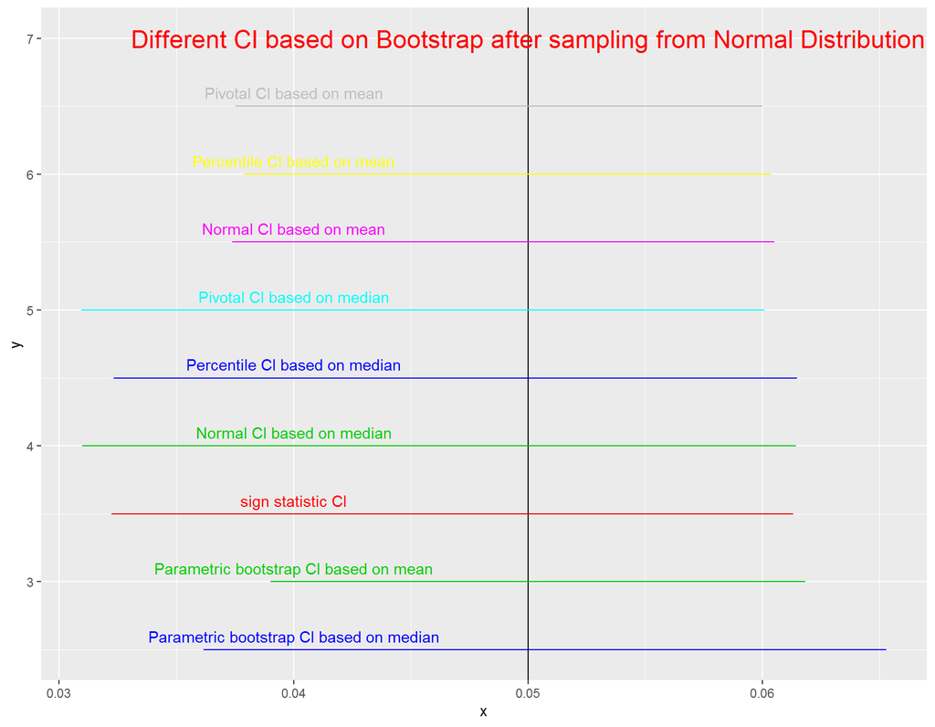

So from our simulation study we observe that it is much better to apply parametric bootstrap than Sign Statistic approach to construct confidence interval for the location parameter.But one big lesson we have learned from the simulation studies is that we should investigate the nature of distribution (from which the sample is coming) very carefully to decide which estimator for population parameter we should use for parametric bootstrap.